# Análise de Focos de Incêndios na Amazônia

## Imports

```r
library(sf)
library(raster)
library(tidyverse)
library(lubridate)
library(spatstat)
```

Os pacotes `sf` e `raster` são essenciais para a manipulação de dados vetoriais e matriciais respectivamente. O pacote `tidyverse` contém funções uteis para a manipulação de tabelas. O pacote `lubridate` é utilizado para converter e manipular datas. Finalmente, o pacote `spatstat` é utilizado para extrair estatisticas espaciais como a densidade de focos.

## Lista de dados

- **Focos de incêndio**: Dados obtidos do [banco de dados de informações sobre queimadas](https://queimadas.dgi.inpe.br/queimadas/bdqueimadas) do INPE Os dados aqui utilizados foram delimitados dentro do bioma Amazônia, entre os anos de 2011 e 2020.
- **Distância à rodovia mais próxima**: A distância euclidiana à rodovia mais proxima foi extraida com base no shapefile de rodovias.
- **Áreas desmatadas**: Dados obtidos em formato vetorial, elaborados pelo PRODES (INPE).

## Leitura dos dados

Primeiramente os dados são carregados utilizando as funções `st_read` e `raster`, e em seguida as funções `extract` e `st_join` são utilizadas para associar os valores de distância e ano de desmatamento ao shapefile de focos.

```r
defor <- st_read("deforestation_reproject.shp")
dist <- raster("prox.tif")
focos <- st_read("focos_2011_2020.shp") %>%
  mutate(dist_rod = raster::extract(dist, .)) %>%
  st_join(defor["year"])
```

## Limpeza dos dados

Em seguida foram removidas algumas variáveis irrelevantes ao estudo e foram adicionadas as variáveis de data.

```r
focos2 <- focos %>%
  as_tibble() %>%
  rename(ano_desm=year) %>%
  select(-satelite, -pais, -(bioma:path), -geometry) %>%
  separate(datahora, c("data", "hora"), " ") %>%
  separate(data, c("ano", "mes", "dia"), "/") %>%
  mutate(data = make_date(ano, mes, dia)) %>%
  mutate(dia_sem = wday(data, label=T)) %>%
  select(-hora)
```

A seguinte função pode ser utilizada então para salvar os dados no formato `.rds`:

```r
## Salvar a tabela
write_rds(focos2, "tabela_focos.rds", compress="gz")
```

Para ler a tabela salva previamente, a seguinte função pode ser utilizada:

```r
## Ler a tabela
focos2 <- read_rds("tabela_focos.rds")

## Visualisar a tabela
focos2
```

| ano | mes | dia | estado | municipio | dist_rod | ano_desm | data | dia_sem |
| --- | --- | --- | --- | --- | --- | --- | --- | --- |
| 2011 | 07 | 04 | PARA | ITAITUBA | 64055.6406 | NA | 2011-07-04 | Mon |
| 2011 | 11 | 30 | PARA | INHANGAPI | 3250.0000 | NA | 2011-11-30 | Wed |
| 2011 | 11 | 30 | PARA | MOCAJUBA | 8975.6611 | NA | 2011-11-30 | Wed |
| 2011 | 12 | 05 | PARA | MOJU | 22534.6953 | NA | 2011-12-05 | Mon |
| 2011 | 12 | 10 | PARA | PRAINHA | 6543.1260 | NA | 2011-12-10 | Sat |
| 2011 | 12 | 17 | PARA | PRAINHA | 9572.0947 | NA | 2011-12-17 | Sat |
| 2011 | 12 | 28 | PARA | PACAJA | 8200.6104 | 2009 | 2011-12-28 | Wed |
| 2011 | 09 | 18 | PARA | ITUPIRANGA | 3716.5171 | NA | 2011-09-18 | Sun |
| 2011 | 11 | 22 | PARA | PLACAS | 16688.3203 | NA | 2011-11-22 | Tue |
| 2011 | 07 | 05 | PARA | SAO GERALDO DO ARAGUAIA | 4981.2144 | NA | 2011-07-05 | Tue |

[output cut: 9990 more lines]

## Algumas estatísticas de distribuição

### Distribuição de focos por estado

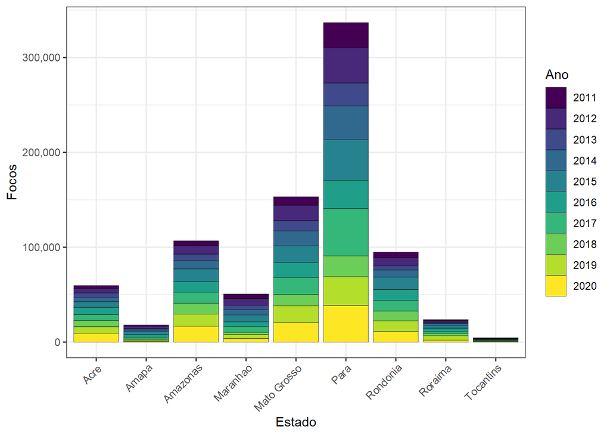

```r
focos2 %>%
  count(ano, estado) %>%
  ggplot(aes(str_to_title(estado), n, fill = ano))+
    geom_col(color="black", size=0.1)+
    scale_fill_viridis_d("Ano")+
    xlab("Estado")+
    ylab("Focos")+
    scale_y_continuous(labels = scales::comma)+
    theme(axis.text.x = element_text(angle = 45, vjust=1, hjust=1))
```

### Variação de focos por mês

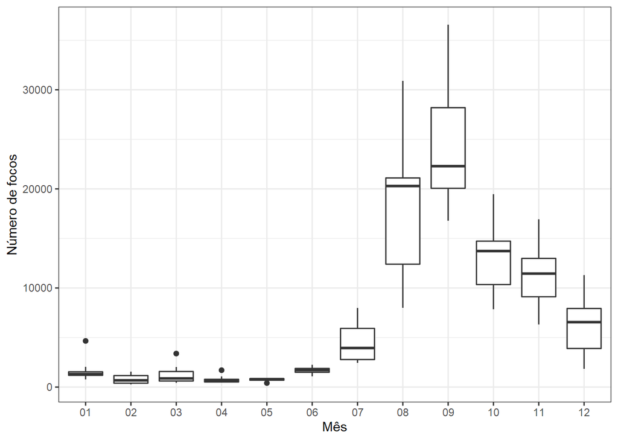

```r
focos2 %>%
  count(ano, mes) %>%
  ggplot(aes(mes, n))+geom_boxplot()+ylab("Número de focos")+xlab("Mês")
```

### Média de focos ao longo do ano

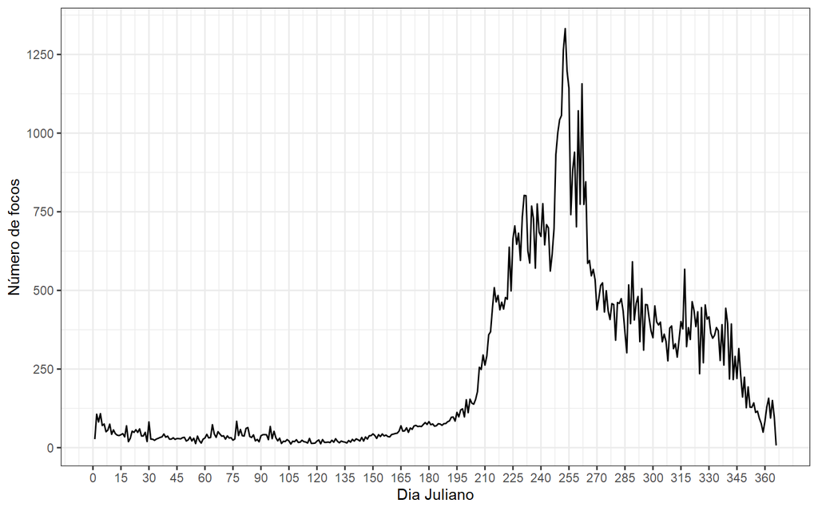

```r
focos2 %>%
  count(dia_jul=yday(data), sort = T) %>%
  ggplot(aes(dia_jul, n/10))+
    geom_line()+
    xlab("Dia Juliano")+
    ylab("Número de focos")+
    scale_x_continuous(breaks=seq(0, 370,15))+
    scale_y_continuous(breaks=seq(0,2000,250))
```

Frequência média por estado:

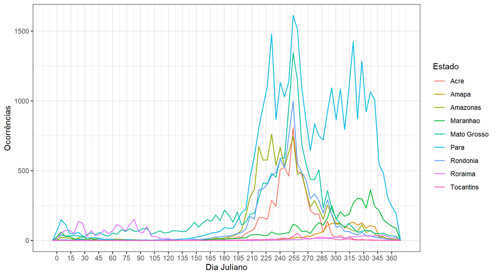

```r
focos2 %>%
  ggplot(aes(yday(data), color=estado))+
    geom_freqpoly(aes(y=..count../10),bins=80)+
    xlab("Dia Juliano")+
    ylab("Ocorrências")+
    scale_x_continuous(breaks=seq(0, 370,15))+
    scale_color_hue("Estado", labels=str_to_title)
```

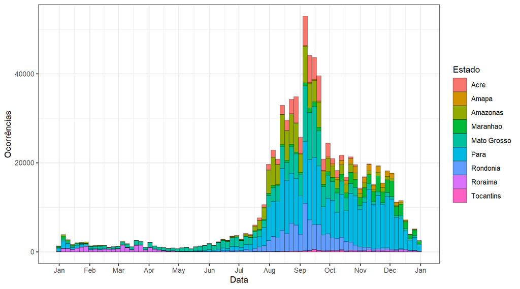

```r
focos2 %>%
  ggplot(aes(x=(as.Date("2020-01-01")+yday(data)-1), fill=estado))+
    geom_histogram(bins=80, boundary=0, color="black", size=0.1)+
    xlab("Data")+
    ylab("Ocorrências")+
    scale_x_date(date_labels = "%b", date_breaks = "1 month")+
    scale_fill_hue("Estado", labels=str_to_title)
```

### Piores municipios (média de focos anuais)

```r
focos2 %>%
  count(ano, municipio) %>%
  group_by(municipio) %>%
  summarise(media=mean(n)) %>%
  arrange(desc(media))
```

| municipio | media |
| --- | --- |
| SAO FELIX DO XINGU | 3097.500000 |
| ALTAMIRA | 2785.500000 |
| PORTO VELHO | 2765.000000 |
| NOVO PROGRESSO | 1598.700000 |
| COLNIZA | 1585.600000 |
| LABREA | 1491.800000 |
| APUI | 1310.300000 |
| ITAITUBA | 1204.700000 |
| NOVA MAMORE | 1023.700000 |
| PACAJA | 967.200000 |

[output cut: 534 more lines]

### Piores anos

```r
focos2 %>%
  count(ano, sort=TRUE)
```

| ano | n |
| --- | --- |
| 2017 | 107439 |
| 2015 | 106438 |
| 2020 | 103164 |
| 2019 | 89177 |
| 2016 | 87762 |
| 2012 | 86719 |
| 2014 | 82554 |
| 2018 | 68345 |
| 2013 | 58688 |
| 2011 | 58186 |

### Piores meses:

```r
focos2 %>%
  count(mes, sort=TRUE)
```

| mes | n |
| --- | --- |
| 09 | 241463 |
| 08 | 188931 |
| 10 | 132034 |
| 11 | 111007 |
| 12 | 61900 |
| 07 | 44670 |
| 06 | 16853 |
| 01 | 16286 |
| 03 | 12374 |
| 02 | 7993 |

[output cut: 2 more lines]

### Totais anuais por estado:

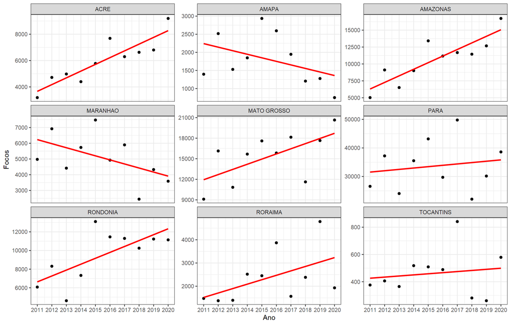

```r
focos2 %>%
  count(ano, estado, sort=T) %>%
  ggplot(aes(x=as.numeric(ano), y=n))+
    geom_point()+
    geom_smooth(se=F, method="lm", formula = y ~ x, color="red")+
    scale_x_continuous(breaks=seq(2011,2020,1))+
    ylab("Focos")+
    xlab("Ano")+
    facet_wrap(vars(estado), ncol=3, scales="free_y")
```

### Variação de focos por distância à rodovia mais próxima

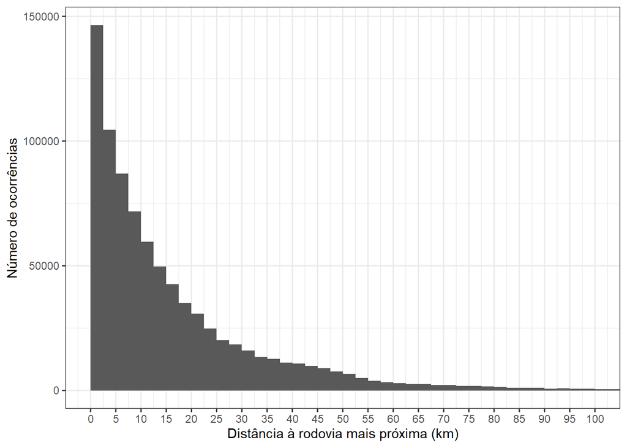

```r
focos2 %>%
  ggplot(aes(dist_rod/1000))+
    geom_histogram(binwidth = 2.5, boundary = 0)+
    coord_cartesian(xlim = c(0,100))+
    scale_x_continuous(breaks=seq(0,100,5))+
    xlab("Distância à rodovia mais próxima (km)")+
    ylab("Número de ocorrências")
```

### Distância média, desvio padrão e percentís (km) por estado:

```r
percentis <- focos2 %>%
  group_by(estado) %>%
  mutate(dist_rod = dist_rod/1000) %>%
  summarise(quants = quantile(dist_rod, c(0.25,0.5,0.75)),
            percents = c("25%", "50%", "75%"),
            media = mean(dist_rod),
            desv_pad = sd(dist_rod)) %>%
  pivot_wider(names_from = c(percents), values_from = quants) %>%
  ungroup()
percentis
```

| estado | media | desv_pad | 25% | 50% | 75% |
| --- | --- | --- | --- | --- | --- |
| ACRE | 27.548348 | 34.908500 | 6.600189 | 14.630875 | 31.667215 |
| AMAPA | 13.642676 | 15.563924 | 2.462214 | 7.520804 | 20.518283 |
| AMAZONAS | 40.340809 | 52.851406 | 8.062258 | 19.264605 | 47.173219 |
| MARANHAO | 6.059299 | 5.644301 | 1.903943 | 4.373214 | 8.500000 |
| MATO GROSSO | 11.871939 | 12.216188 | 3.363406 | 8.162414 | 16.081821 |
| PARA | 18.293621 | 23.750221 | 4.007805 | 10.511898 | 23.734205 |
| RONDONIA | 19.257874 | 16.642342 | 5.755432 | 14.758473 | 28.558055 |
| RORAIMA | 14.479197 | 29.150191 | 3.250000 | 8.000000 | 16.263456 |
| TOCANTINS | 4.514309 | 3.895130 | 1.457738 | 3.354102 | 6.754628 |

### Valores médios gerais:

```r
percentis %>%
  summarise(across(media:`75%`, mean))
```

| media | desv_pad | 25% | 50% | 75% |
| --- | --- | --- | --- | --- |
| 17.33423 | 21.62469 | 4.095887 | 10.06404 | 22.13899 |

### Ocorrências de focos em áreas desmatadas

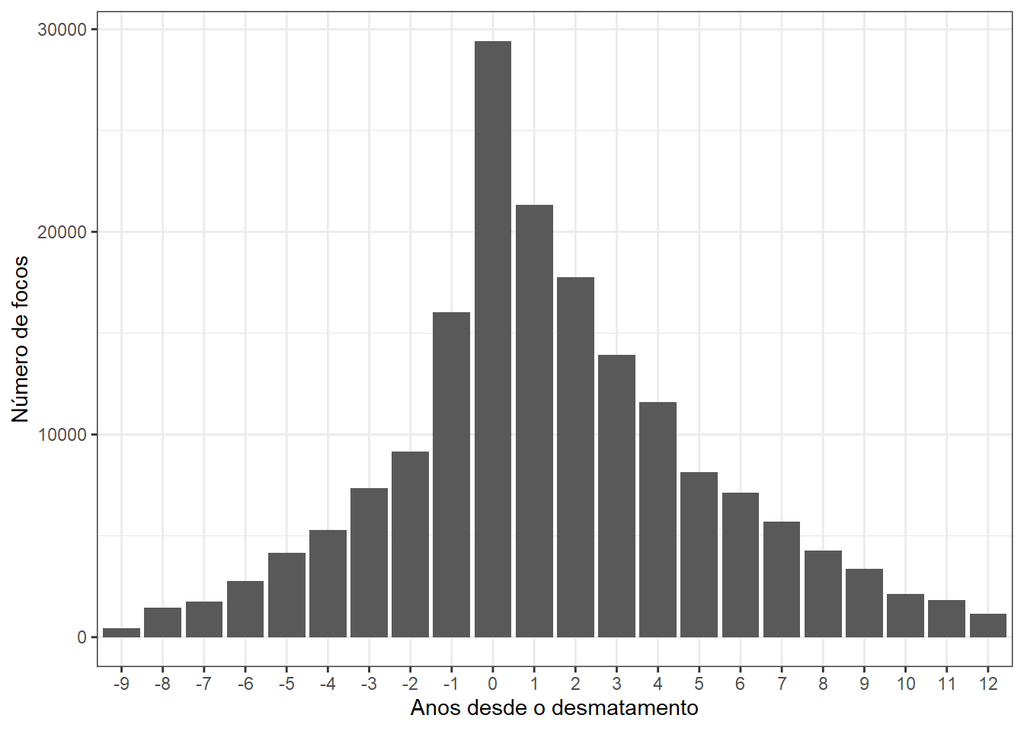

```r
focos2 %>%
  drop_na(ano_desm) %>%
  count(anos_desmatado = as.numeric(ano)-ano_desm) %>%
  filter(anos_desmatado >=-12) %>%
  ggplot(aes(factor(anos_desmatado), n))+geom_col()+xlab("Anos desde o desmatamento")+ylab("Número de focos")
```

Número de focos que ocorreram em áreas *previamente* ou *posteriormente* desmatadas:

```r
focos2 %>%
  mutate(anos_desmatado = as.numeric(ano)-ano_desm) %>%
  count(tipo = anos_desmatado >=0) %>%
  mutate(tipo = c("área posteriormente desmatada",
                  "área anteriormente desmatada",
                  "área não desmatada"),
         `%` = n/sum(n)*100)
```

| tipo | n | % |
| --- | --- | --- |
| área posteriormente desmatada | 48498 | 5.715922 |
| área anteriormente desmatada | 127772 | 15.059071 |
| área não desmatada | 672202 | 79.225007 |

## Estatísticas espaciais

```r
focos <- st_read("focos_2011_2020.shp")
am <- st_read("amazonia_legal.shp")
```

```r
am_owin <- as.owin(am)
focos_ppp <- as.ppp(focos)
marks(focos_ppp) <- NULL
Window(focos_ppp) <- am_owin
write_rds(focos_ppp, "focos_ppp.rds", compress="gz")
```

### Densidade de focos

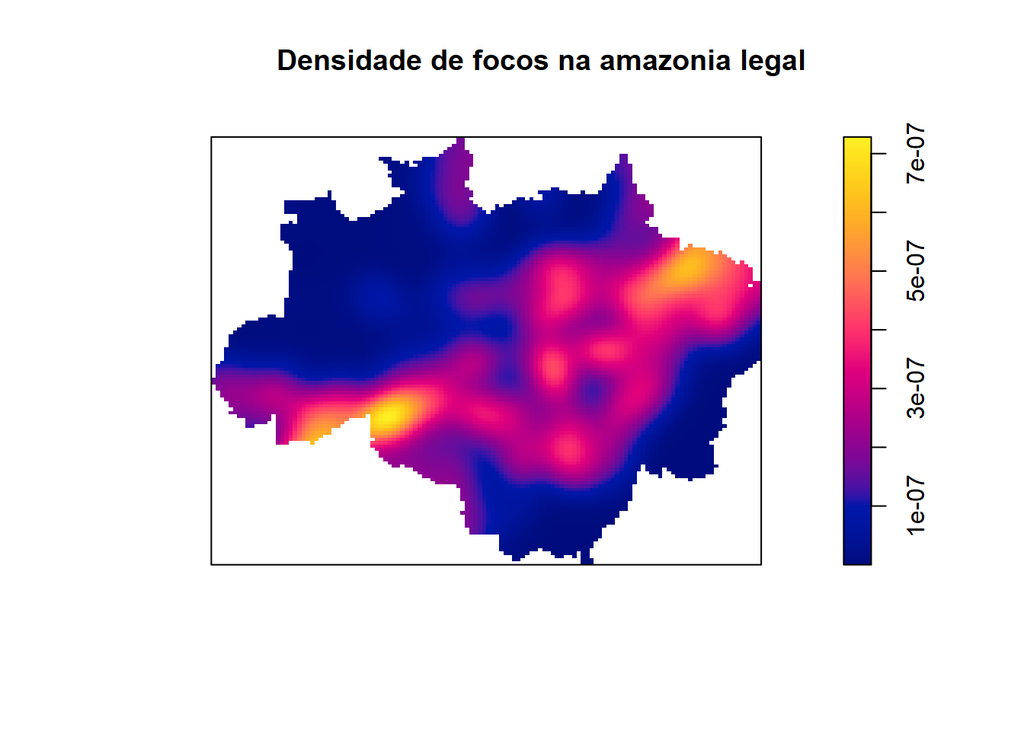

```r
ds <- density(focos_ppp, sigma=100000)
plot(ds, main="Densidade de focos na amazonia legal")
```